# Solution

### Philosophy Module

This module aimed to verify **Personal philosophy on Science, Products and Health**

```r
survey_philosophy <-
  survey_data %>%
  select(response_id, contains('m1_philosophy'))
```

Preprocessing of the data

```r
survey_philosophy <- as.data.frame(survey_philosophy) #change the structure of the data to a data frame to be easy to manipulate
survey_philosophy <- survey_philosophy[-1] # remove the response_id column
head(survey_philosophy) #Visualise the data
```

```
#>   m1_philosophy_1 m1_philosophy_2 m1_philosophy_3 m1_philosophy_4
#> 1               3               3               3               4
#> 2               4               2               3               5
#> 3               4               3               3               3
#> 4               5               1               5               3
#> 5               4               1               5               4
#> 6               4               1               5               4
#>   m1_philosophy_5 m1_philosophy_6 m1_philosophy_7 m1_philosophy_8
#> 1               3               2               4               4
#> 2               5               4               3               5
#> 3               2               3               4               4
#> 4               5               4               4               4
#> 5               3               1               3               4
#> 6               2               4               4               5
#>   m1_philosophy_9
#> 1               3
#> 2               4
#> 3               4
#> 4               5
#> 5               5
#> 6               4
```

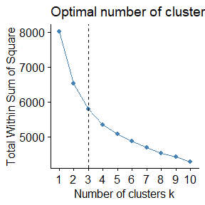

```r
survey_philosophy <- na.omit(survey_philosophy) #remove any missing data
survey_philosophy_scaled <- scale(survey_philosophy) #scale the data to be easier and more confident for clustering
fviz_nbclust(survey_philosophy_scaled, kmeans, method = "wss") +
geom_vline(xintercept = 3, linetype = 2) #Identification of cluster number in the scaled data, 3 cluster can be good for the job because beyond the 5 additional cluster have a little value.
```

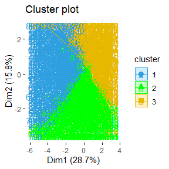

```r
# Compute k-means with k = 3
set.seed(123)
survey_philosophy_km <- kmeans(survey_philosophy_scaled, centers = 3, nstart = 50) #we select nstart 50 to have a more stable result
factoextra::fviz_cluster(survey_philosophy_km, data = survey_philosophy  , #visualisation of the clusters
palette = c("#2E9FDF", "green", "#E7B800", "#FC4E07", "red"),
ellipse.type = "euclid", # Concentration ellipse
star.plot = TRUE, # Add segments from centroids to items
repel = TRUE, # Avoid label overplotting (slow)
ggtheme = theme_minimal()
)
```

Interpretation

```r
survey_philosophy_cl <- cbind(survey_philosophy, cluster = survey_philosophy_km$cluster) #Add the cluster to the original data
survey_philosophy_cluster_count <- count(survey_philosophy_cl,cluster) #count the number of customer per cluster
head(survey_philosophy_cluster_count)
```

```
#>   cluster   n
#> 1       1 347
#> 2       2 308
#> 3       3 237
```

The customers are much represented in cluster 1.

```r
(survey_philosophy_cluster_result<- survey_philosophy_cl%>%group_by(cluster)%>%summarise_all(list(mean))%>%round()) # get the final result of the mean of each attribute per cluster and round them to make the analysis easier
```

```
#> # A tibble: 3 x 10
#>   cluster m1_philosophy_1 m1_philosophy_2 m1_philosophy_3 m1_philosophy_4
#>     <dbl>           <dbl>           <dbl>           <dbl>           <dbl>
#> 1       1               3               3               3               3
#> 2       2               4               2               4               4
#> 3       3               4               4               4               4
#> # ... with 5 more variables: m1_philosophy_5 <dbl>, m1_philosophy_6 <dbl>,
#> #   m1_philosophy_7 <dbl>, m1_philosophy_8 <dbl>, m1_philosophy_9 <dbl>
```

We can divide the customers into three significants groups with these highlights information. Two groups over 3 agree on the evidence of medical advice for their health. They do not agree for the importance of scientific research on society, but a little part of them somewhat agree. They somewhat agree about the rightness of western medicine approach. They somewhat agree about the product based on immediate health rather than long term one. The two groups differ on the attribute stands for trying new product known for heath benefits. The first ones majority neither agree or disagree but the last somewhat agree. According to the fact they would like to know about how the product impact their health, the majority somewhat agree, but the rest neither agree or disagree. The majority somewhat agree on the fact that their personal wellness is one of their top priorities. The majority somewhat agree on their skeptically mood about the value of health supplements that are not regulated by the Food & Drug Administration (FDA)

### Awareness Module

This module aimed to check **Attitudes & Awareness** towards statements related to sleep.

```r
survey_awareness <-
  survey_data %>%
    select(response_id, contains('m2_awareness'))
head(survey_awareness,1)
```

```
#> # A tibble: 1 x 13
#>   response_id m2_awareness_ap~ m2_awareness_ap~ m2_awareness_ap~
#>   <chr>              <dbl+lbl>        <dbl+lbl>        <dbl+lbl>
#> 1 R_4YgkQnMw~               NA               NA               NA
#> # ... with 9 more variables: m2_awareness_apps_6 <dbl+lbl>,
#> #   m2_awareness_apps_7 <dbl+lbl>, m2_awareness_apps_8 <dbl+lbl>,
#> #   m2_awareness_apps_9 <dbl+lbl>, m2_awareness_apps_10 <dbl+lbl>,
#> #   m2_awareness_apps_11 <dbl+lbl>, m2_awareness_apps_12 <dbl+lbl>,
#> #   m2_awareness_apps_13 <dbl+lbl>, m2_awareness_apps_14 <dbl+lbl>
```

Pre processing of the data

```r
survey_awareness <- as.data.frame(survey_awareness) #change the structure of the data to a data frame to be easy to manipulate
survey_awareness <- survey_awareness[-1] # remove the response_id column
head(survey_awareness) #Visualise the data
```

```
#>   m2_awareness_apps_1 m2_awareness_apps_4 m2_awareness_apps_5
#> 1                  NA                  NA                  NA
#> 2                  NA                  NA                  NA
#> 3                   1                  NA                  NA
#> 4                  NA                  NA                  NA
#> 5                  NA                  NA                  NA
#> 6                  NA                  NA                  NA
#>   m2_awareness_apps_6 m2_awareness_apps_7 m2_awareness_apps_8
#> 1                  NA                  NA                  NA
#> 2                  NA                  NA                  NA
#> 3                  NA                  NA                   1
#> 4                  NA                  NA                  NA
#> 5                  NA                  NA                  NA
#> 6                  NA                  NA                   1
#>   m2_awareness_apps_9 m2_awareness_apps_10 m2_awareness_apps_11
#> 1                  NA                   NA                   NA
#> 2                   1                   NA                   NA
#> 3                   1                   NA                   NA
#> 4                  NA                   NA                   NA
#> 5                   1                   NA                   NA
#> 6                   1                   NA                   NA
#>   m2_awareness_apps_12 m2_awareness_apps_13 m2_awareness_apps_14
#> 1                   NA                   NA                    1
#> 2                   NA                   NA                   NA
#> 3                   NA                   NA                   NA
#> 4                   NA                   NA                    1
#> 5                   NA                   NA                   NA
#> 6                   NA                   NA                   NA
```

```r
survey_awareness[is.na(survey_awareness)] <- 0
head(survey_awareness)
```

```
#>   m2_awareness_apps_1 m2_awareness_apps_4 m2_awareness_apps_5
#> 1                   0                   0                   0
#> 2                   0                   0                   0
#> 3                   1                   0                   0
#> 4                   0                   0                   0
#> 5                   0                   0                   0
#> 6                   0                   0                   0
#>   m2_awareness_apps_6 m2_awareness_apps_7 m2_awareness_apps_8
#> 1                   0                   0                   0
#> 2                   0                   0                   0
#> 3                   0                   0                   1
#> 4                   0                   0                   0
#> 5                   0                   0                   0
#> 6                   0                   0                   1
#>   m2_awareness_apps_9 m2_awareness_apps_10 m2_awareness_apps_11
#> 1                   0                    0                    0
#> 2                   1                    0                    0
#> 3                   1                    0                    0
#> 4                   0                    0                    0
#> 5                   1                    0                    0
#> 6                   1                    0                    0
#>   m2_awareness_apps_12 m2_awareness_apps_13 m2_awareness_apps_14
#> 1                    0                    0                    1
#> 2                    0                    0                    0
#> 3                    0                    0                    0
#> 4                    0                    0                    1
#> 5                    0                    0                    0
#> 6                    0                    0                    0
```

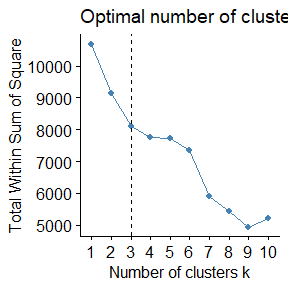

```r
survey_awareness_scaled <- scale(survey_awareness)
fviz_nbclust(survey_awareness_scaled, kmeans, method = "wss") +
geom_vline(xintercept = 3, linetype = 2) #Identification of cluster number in the scaled data, 3 cluster can be good for the job because beyond the 5 additional cluster have a little value.
```

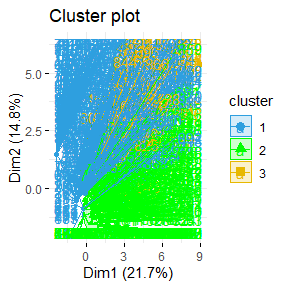

```r
# Compute k-means with k = 3
set.seed(123)
survey_awareness_km <- kmeans(survey_awareness_scaled, centers = 3, nstart = 50) #we select nstart 50 to have a more stable result
factoextra::fviz_cluster(survey_awareness_km, data = survey_awareness  , #visualisation of the clusters
palette = c("#2E9FDF", "green", "#E7B800", "#FC4E07", "red"),
ellipse.type = "euclid", # Concentration ellipse
star.plot = TRUE, # Add segments from centroids to items
repel = TRUE, # Avoid label overplotting (slow)
ggtheme = theme_minimal()
)
```

Interpretation

```r
survey_awareness_cl <- cbind(survey_awareness, cluster = survey_awareness_km$cluster) #Add the cluster to the original data
survey_awareness_cluster_count <- count(survey_awareness_cl,cluster) #count the number of customer per cluster
survey_awareness_cluster_count
```

```
#>   cluster   n
#> 1       1 441
#> 2       2 380
#> 3       3  71
```

The customers are much represented in cluster 1.

```r
(survey_awareness_cluster_result<- survey_awareness_cl %>% group_by(cluster)%>%summarise_all(list(mean))%>%round())# get the final result of the mean of each attribute per cluster and round them to make the analysis easier
```

```
#> # A tibble: 3 x 13
#>   cluster m2_awareness_ap~ m2_awareness_ap~ m2_awareness_ap~ m2_awareness_ap~
#>     <dbl>            <dbl>            <dbl>            <dbl>            <dbl>
#> 1       1                0                0                0                0
#> 2       2                1                0                0                1
#> 3       3                0                1                0                1
#> # ... with 8 more variables: m2_awareness_apps_7 <dbl>,
#> #   m2_awareness_apps_8 <dbl>, m2_awareness_apps_9 <dbl>,
#> #   m2_awareness_apps_10 <dbl>, m2_awareness_apps_11 <dbl>,
#> #   m2_awareness_apps_12 <dbl>, m2_awareness_apps_13 <dbl>,
#> #   m2_awareness_apps_14 <dbl>
```

### Source & Solutions Module

This module asked about **sources of trouble with sleeping** at night and any **actions taken to improve the quality of sleep**.

### Source question

> Thinking about the past year, what are the primary reasons you have trouble sleeping at night? Select up to three.

```r
survey_source <-
  survey_data %>%
    select(response_id, contains('source'))
head(survey_source,1)
```

```
#> # A tibble: 1 x 16
#>   response_id source_1 source_4 source_5 source_6 source_7 source_8 source_9
#>   <chr>       <dbl+lb> <dbl+lb> <dbl+lb> <dbl+lb> <dbl+lb> <dbl+lb> <dbl+lb>
#> 1 R_4YgkQnMw~       NA       NA       NA       NA       NA       NA       NA
#> # ... with 8 more variables: source_10 <dbl+lbl>, source_11 <dbl+lbl>,
#> #   source_12 <dbl+lbl>, source_13 <dbl+lbl>, source_14 <dbl+lbl>,
#> #   source_15 <dbl+lbl>, source_16 <dbl+lbl>, source_17 <dbl+lbl>
```

```r
survey_source <- as.data.frame(survey_source) #change the structure of the data to a data frame to be easy to manipulate

survey_source <- survey_source[-1] # remove the response_id column
survey_source[is.na(survey_source)] <- 0
head(survey_source,1) #Visualise the data
```

```
#>   source_1 source_4 source_5 source_6 source_7 source_8 source_9 source_10
#> 1        0        0        0        0        0        0        0         0
#>   source_11 source_12 source_13 source_14 source_15 source_16 source_17
#> 1         1         0         0         0         0         0         0
```

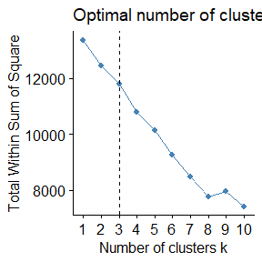

```r
survey_source_scaled <- scale(survey_source)
fviz_nbclust(survey_source_scaled, kmeans, method = "wss") +
geom_vline(xintercept = 3, linetype = 2) #Identification of cluster number in the scaled data, 3 cluster can be good for the job because beyond the 5 additional cluster have a little value.
```

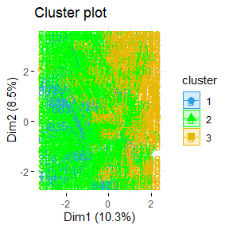

```r
# Compute k-means with k = 3
set.seed(123)
survey_source_km <- kmeans(survey_source_scaled, centers = 3, nstart = 50) #we select nstart 50 to have a more stable result
factoextra::fviz_cluster(survey_source_km, data = survey_source  , #visualisation of the clusters
palette = c("#2E9FDF", "green", "#E7B800", "#FC4E07", "red"),
ellipse.type = "euclid", # Concentration ellipse
star.plot = TRUE, # Add segments from centroids to items
repel = TRUE, # Avoid label overplotting (slow)
ggtheme = theme_minimal()
)
```

Interpretation

```r
survey_source_cl <- cbind(survey_source, cluster = survey_source_km$cluster) #Add the cluster to the original data
survey_source_cluster_count <- count(survey_source_cl,cluster) #count the number of customer per cluster
head(survey_source_cluster_count)
```

```
#>   cluster   n
#> 1       1  57
#> 2       2 551
#> 3       3 284
```

```r
(survey_source_cluster_result<- survey_source_cl%>%group_by(cluster)%>%summarise_all(list(mean))%>%round())# get the final result of the mean of each attribute per cluster and round them to make the analysis easier
```

```
#> # A tibble: 3 x 16
#>   cluster source_1 source_4 source_5 source_6 source_7 source_8 source_9
#>     <dbl>    <dbl>    <dbl>    <dbl>    <dbl>    <dbl>    <dbl>    <dbl>
#> 1       1        0        0        0        0        0        0        0
#> 2       2        0        0        0        0        0        0        0
#> 3       3        0        0        0        0        0        0        1
#> # ... with 8 more variables: source_10 <dbl>, source_11 <dbl>, source_12 <dbl>,
#> #   source_13 <dbl>, source_14 <dbl>, source_15 <dbl>, source_16 <dbl>,
#> #   source_17 <dbl>
```

The primary reasons for sleeping trouble at night for the first group is medication, the second group did not have and the for last group is the Stress from personal life events.

### Behavioral questions

```r
survey_behavior <-
  survey_data %>%
    select(response_id, contains('behavior'))
head(survey_behavior)
```

```
#> # A tibble: 6 x 29
#>   response_id behavior_1 behavior_4 behavior_5 behavior_6 behavior_7 behavior_8
#>   <chr>        <dbl+lbl>  <dbl+lbl>  <dbl+lbl>  <dbl+lbl>  <dbl+lbl>  <dbl+lbl>
#> 1 R_4YgkQnMw~         NA NA          1 [Stuck~ NA                 NA NA
#> 2 R_ZKuM4msZ~         NA NA         NA         NA                 NA  1 [Tried~
#> 3 R_1lntx0Em~         NA NA          1 [Stuck~ NA                 NA NA
#> 4 R_29j2Ko8y~         NA NA         NA         NA                 NA NA
#> 5 R_2feXgKJV~         NA NA         NA         NA                 NA NA
#> 6 R_1HqylZO7~         NA  1 [Talke~ NA          1 [Track~         NA  1 [Tried~
#> # ... with 22 more variables: behavior_9 <dbl+lbl>, behavior_10 <dbl+lbl>,
#> #   behavior_11 <dbl+lbl>, behavior_12 <dbl+lbl>, behavior_13 <dbl+lbl>,
#> #   behavior_14 <dbl+lbl>, behavior_15 <dbl+lbl>, behavior_16 <dbl+lbl>,
#> #   behavior_a_1 <dbl+lbl>, behavior_a_2 <dbl+lbl>, behavior_a_3 <dbl+lbl>,
#> #   behavior_a_4 <dbl+lbl>, behavior_a_5 <dbl+lbl>, behavior_a_6 <dbl+lbl>,
#> #   behavior_a_7 <dbl+lbl>, behavior_a_8 <dbl+lbl>, behavior_a_9 <dbl+lbl>,
#> #   behavior_a_10 <dbl+lbl>, behavior_a_11 <dbl+lbl>, behavior_a_12 <dbl+lbl>,
#> #   behavior_a_13 <dbl+lbl>, behavior_a_14 <dbl+lbl>
```

```r
survey_behavior <-
  survey_data %>%
    select(response_id, contains('behavior'))
head(survey_behavior)
```

```
#> # A tibble: 6 x 29
#>   response_id behavior_1 behavior_4 behavior_5 behavior_6 behavior_7 behavior_8
#>   <chr>        <dbl+lbl>  <dbl+lbl>  <dbl+lbl>  <dbl+lbl>  <dbl+lbl>  <dbl+lbl>
#> 1 R_4YgkQnMw~         NA NA          1 [Stuck~ NA                 NA NA
#> 2 R_ZKuM4msZ~         NA NA         NA         NA                 NA  1 [Tried~
#> 3 R_1lntx0Em~         NA NA          1 [Stuck~ NA                 NA NA
#> 4 R_29j2Ko8y~         NA NA         NA         NA                 NA NA
#> 5 R_2feXgKJV~         NA NA         NA         NA                 NA NA
#> 6 R_1HqylZO7~         NA  1 [Talke~ NA          1 [Track~         NA  1 [Tried~
#> # ... with 22 more variables: behavior_9 <dbl+lbl>, behavior_10 <dbl+lbl>,
#> #   behavior_11 <dbl+lbl>, behavior_12 <dbl+lbl>, behavior_13 <dbl+lbl>,
#> #   behavior_14 <dbl+lbl>, behavior_15 <dbl+lbl>, behavior_16 <dbl+lbl>,
#> #   behavior_a_1 <dbl+lbl>, behavior_a_2 <dbl+lbl>, behavior_a_3 <dbl+lbl>,
#> #   behavior_a_4 <dbl+lbl>, behavior_a_5 <dbl+lbl>, behavior_a_6 <dbl+lbl>,
#> #   behavior_a_7 <dbl+lbl>, behavior_a_8 <dbl+lbl>, behavior_a_9 <dbl+lbl>,
#> #   behavior_a_10 <dbl+lbl>, behavior_a_11 <dbl+lbl>, behavior_a_12 <dbl+lbl>,
#> #   behavior_a_13 <dbl+lbl>, behavior_a_14 <dbl+lbl>
```

```r
survey_behavior <- as.data.frame(survey_behavior) #change the structure of the data to a data frame to be easy to manipulate
survey_behavior <- survey_behavior[-1] # remove the response_id column
survey_behavior[is.na(survey_behavior)] <- 0 #Change the Na value to 0

#Delete the colums that have 0 as sum.
      for (i in colnames(survey_behavior)){
        if(sum(survey_behavior$i) < 1){
         dataNumber = which(colnames(survey_behavior)==i)
        }}
survey_behavior <- survey_behavior[-dataNumber]

head(survey_behavior)#Visualise the data
```

```
#>   behavior_1 behavior_4 behavior_5 behavior_6 behavior_7 behavior_8 behavior_9
#> 1          0          0          1          0          0          0          0
#> 2          0          0          0          0          0          1          0
#> 3          0          0          1          0          0          0          0
#> 4          0          0          0          0          0          0          0
#> 5          0          0          0          0          0          0          0
#> 6          0          1          0          1          0          1          1
#>   behavior_10 behavior_11 behavior_12 behavior_13 behavior_14 behavior_15
#> 1           0           0           0           0           0           0
#> 2           0           0           0           0           0           0
#> 3           0           0           0           1           1           0
#> 4           0           0           0           0           0           0
#> 5           0           0           0           0           0           0
#> 6           0           0           1           0           0           0
#>   behavior_16 behavior_a_1 behavior_a_2 behavior_a_3 behavior_a_4 behavior_a_5
```

[output cut: 20 more lines]

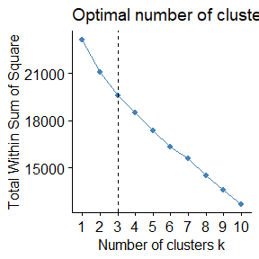

```r
survey_behavior_scaled <- scale(survey_behavior[-ncol(survey_behavior)])
fviz_nbclust(survey_behavior_scaled, kmeans, method = "wss") +
geom_vline(xintercept = 3, linetype = 2) #Identification of cluster number in the scaled data, 3 cluster can be good for the job because beyond the 5 additional cluster have a little value.
```

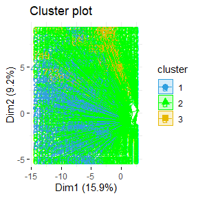

```r
# Compute k-means with k = 3
set.seed(123)
survey_behavior_km <- kmeans(survey_behavior_scaled, centers = 3, nstart = 50) #we select nstart 50 to have a more stable result
factoextra::fviz_cluster(survey_behavior_km, data = survey_behavior  , #visualisation of the clusters
palette = c("#2E9FDF", "green", "#E7B800", "#FC4E07", "red"),
ellipse.type = "euclid", # Concentration ellipse
star.plot = TRUE, # Add segments from centroids to items
repel = TRUE, # Avoid label overplotting (slow)
ggtheme = theme_minimal()
)
```

Interpretation

```r
survey_behavior_cl <- cbind(survey_behavior, cluster = survey_behavior_km$cluster) #Add the cluster to the original data
survey_behavior_cluster_count <- count(survey_behavior_cl,cluster) #count the number of customer per cluster
head(survey_behavior_cluster_count)
```

```
#>   cluster   n
#> 1       1 225
#> 2       2 621
#> 3       3  46
```

```r
(survey_behavior_cluster_result<- survey_behavior_cl%>%group_by(cluster)%>%summarise_all(list(mean))%>%round())# get the final result of the mean of each attribute per cluster and round them to make the analysis easier
```

```
#> # A tibble: 3 x 28
#>   cluster behavior_1 behavior_4 behavior_5 behavior_6 behavior_7 behavior_8
#>     <dbl>      <dbl>      <dbl>      <dbl>      <dbl>      <dbl>      <dbl>
#> 1       1          0          0          0          0          0          0
#> 2       2          0          0          0          0          0          0
#> 3       3          0          0          0          0          0          0
#> # ... with 21 more variables: behavior_9 <dbl>, behavior_10 <dbl>,
#> #   behavior_11 <dbl>, behavior_12 <dbl>, behavior_13 <dbl>, behavior_14 <dbl>,
#> #   behavior_15 <dbl>, behavior_16 <dbl>, behavior_a_1 <dbl>,
#> #   behavior_a_2 <dbl>, behavior_a_3 <dbl>, behavior_a_4 <dbl>,
#> #   behavior_a_5 <dbl>, behavior_a_6 <dbl>, behavior_a_7 <dbl>,
#> #   behavior_a_8 <dbl>, behavior_a_9 <dbl>, behavior_a_10 <dbl>,
#> #   behavior_a_11 <dbl>, behavior_a_12 <dbl>, behavior_a_13 <dbl>
```

Interpretation:

- **The cluster 1** has tried meditation and they’ve made change to reduce stress. They think that talking to a doctor about their trouble sleeping is very successful. **They find very successful the steps they’ve used to improve their sleeping**(Stuck to a nightly routine and Tracked my sleep using an app, website, or journal, Purchased products or devices to improve my sleep, Tried over-the-counter sleep supplements, Tried meditation, Made changes to reduce stress, Altered my diet, Altered my exercise routine).
- **The cluster 2**, they find very successful, the application of theses methods (Stuck to a nightly routine and Tried over-the-counter sleep supplements) as the bests for improving their sleep in the past year.
- **The cluster 3**, they find these methods as the bests ones to improve their sleep.(Tried over-the-counter sleep supplements, Talked to their doctor about trouble sleeping in the past, Tried over-the-counter sleep supplements, Tried prescribed medication and Tried meditation ). They find **Visited a sleep clinic** as somewhat successfull

Other questions related to source and solutions

```r
survey_behavior2 <-
  survey_data %>%
    select(response_id, interst_cbt:interest_coach)
```

```r
head(survey_behavior2)
```

```
#> # A tibble: 6 x 4
#>   response_id                  interst_cbt past_coach             interest_coach
#>   <chr>                          <dbl+lbl>  <dbl+lbl>                  <dbl+lbl>
#> 1 R_4YgkQnMwIBt~ 3 [Neither interested no~     2 [No] 3 [Neither interested nor~
#> 2 R_ZKuM4msZCKK~ 2 [Somewhat interested]       2 [No] 2 [Somewhat interested]
#> 3 R_1lntx0EmZ8g~ 3 [Neither interested no~     2 [No] 3 [Neither interested nor~
#> 4 R_29j2Ko8ydqj~ 2 [Somewhat interested]       2 [No] 2 [Somewhat interested]
#> 5 R_2feXgKJVSlg~ 3 [Neither interested no~     2 [No] 4 [Somewhat uninterested]
#> 6 R_1HqylZO7RPD~ 3 [Neither interested no~     2 [No] 3 [Neither interested nor~
```

```r
survey_behavior2 <- as.data.frame(survey_behavior2) #change the structure of the data to a data frame to be easy to manipulate
survey_behavior2 <- survey_behavior2[-1] # remove the response_id column
head(survey_behavior2)#Visualise the data
```

```
#>   interst_cbt past_coach interest_coach
#> 1           3          2              3
#> 2           2          2              2
#> 3           3          2              3
#> 4           2          2              2
#> 5           3          2              4
#> 6           3          2              3
```

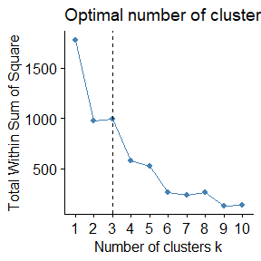

```r
survey_behavior2_scaled <- scale(survey_behavior2[-ncol(survey_behavior2)])
fviz_nbclust(survey_behavior2_scaled, kmeans, method = "wss") +
geom_vline(xintercept = 3, linetype = 2) #Identification of cluster number in the scaled data, 3 cluster can be good for the job because beyond the 5 additional cluster have a little value.
```

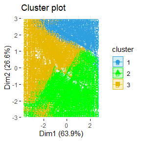

```r
# Compute k-means with k = 3
set.seed(123)
survey_behavior2_km <- kmeans(survey_behavior2_scaled, centers = 3, nstart = 50) #we select nstart 50 to have a more stable result
factoextra::fviz_cluster(survey_behavior2_km, data = survey_behavior2  , #visualisation of the clusters
palette = c("#2E9FDF", "green", "#E7B800", "#FC4E07", "red"),
ellipse.type = "euclid", # Concentration ellipse
star.plot = TRUE, # Add segments from centroids to items
repel = TRUE, # Avoid label overplotting (slow)
ggtheme = theme_minimal()
)
```

Interpretation

```r
survey_behavior2_cl <- cbind(survey_behavior2, cluster = survey_behavior2_km$cluster) #Add the cluster to the original data
survey_behavior2_cluster_count <- count(survey_behavior2_cl,cluster) #count the number of customer per cluster
head(survey_behavior2_cluster_count)
```

```
#>   cluster   n
#> 1       1 169
#> 2       2 375
#> 3       3 348
```

```r
(survey_behavior2_cluster_result<- survey_behavior2_cl%>%group_by(cluster)%>%summarise_all(list(mean))%>%round())# get the final result of the mean of each attribute per cluster and round them to make the analysis easier
```

```
#> # A tibble: 3 x 4
#>   cluster interst_cbt past_coach interest_coach
#>     <dbl>       <dbl>      <dbl>          <dbl>
#> 1       1           2          1              2
#> 2       2           2          2              2
#> 3       3           4          2              4
```